# Exploring temporal signal

Will Harvey

March 20 2023

```r
# load the package into R
library(toolkitSeqTree)

# load other useful packages
library(ggtree)
library(ggplot2)
library(dplyr)
library(lubridate)
```

## Temporal signal in heterochronous sequences

Heterchronous sequences are those sampled at different points in time that have undergone measurable amounts of evolutionary change between sampling times. Given a molecular phylogeny and dates of sampling for each sequence, the function `tree_tempest()` can be used to explore the relationship between genetic divergence through time and sampling date. The presence of temporal signal in sequences sampled through time can be used to assess the suitability of a phylogenetic molecular clock analysis for the sequences.

The function `tree_tempest()` is inspired by the software tool TempEst (Rambaut, Lam, de Carvalho & Pybus, Virus Evolution, 2016, 2(1): vew007) which is available at http://tree.bio.ed.ac.uk/software/tempest/. The TempEst software has various additional features including the ability to identify the root position for which the data appear most ‘clock-like’ (i.e. the root position that minimises distances from the regression line).

### Phylogeny for temporally sampled sequences

This example uses a maximum likelihood phylogenetic tree constructed for 87 concatenated influenza A(H5N8) genomes sampled over a range of dates spanning roughly a year between late 2016 and late 2017. The labels in the tree include the sampling dates which can be extracted after using `ggtree::fortify()` to generate a data frame from the tree object.

The phylogenetic tree has been generated using raxml (https://cme.h-its.org/exelixis/web/software/raxml/).

```r
tree <- treeio::read.tree('../inst/extdata/h5n8_fullGenome.raxml.bestTree.tre')
tree_dat <- fortify(tree)

# extract the part of the taxon labels in the tree that contain sampling date
tree_dat$date <- ifelse(tree_dat$isTip == T,
                        stringr::str_extract(tree_dat$label, '[\\-0-9]+$'),
                        NA)
```

The extracted dates can now be used to colour tip nodes on a plot of the phylogeny.

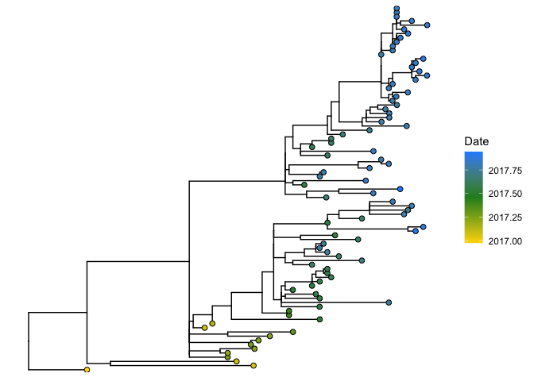

```r
ggtree(tree_dat) +
  geom_tippoint(aes(fill = Date2decimal(date)), pch = 21, size = 2) +
  scale_fill_gradientn(colours = c('gold', 'forestgreen', 'dodgerblue'),
                       name = 'Date')
```

### Using `tree_tempest()`

The data frame generated by `ggtree::fortify()` can be supplied to `tree_tempest()` to explore the relationship between sequence divergence and sampling date. The regression of root-to-tip divergence and samling date gives an idea of the presence of temporal signal. `tree_tempest()` returns some summary statistics associated with this regression and a scatter plot where each point represents a tip node on the phylogeny.

```r
tree_tempest(tree_dat)
```

```
#> Date range: 0.967
#> Slope (rate): 0.005
#> x-intercept (tMRCA): 2016.4
#> Correlation coefficient: 0.929
#> R squared: 0.862
```

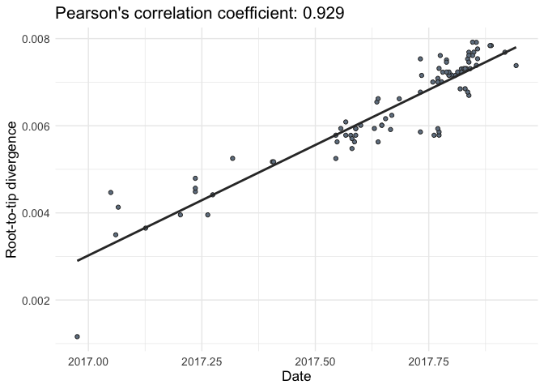

### Using `tree_tempest()` with `residuals = TRUE`

Optionally, `tree_tempest()` can be run with the option `residuals = TRUE` which will return information on the distance of each sequence from the regression line for the regression between root-to-tip distances and sampling dates. A sequence found substantially above or below, the regression line is inferred to be considerably more or less, respectively, genetically diverged from the root than expected given its sampling date. Running the function with `residuals = TRUE` will return a plot of the phylogenetic tree with tips coloured according to the associated residual. Additionally, a data frame with a column containing the residuals will be returned if the option `return_df = TRUE` is used.

```r
tree_tempest(tree_dat, residuals = TRUE)
```

```
#> Date range: 0.967
#> Slope (rate): 0.005
#> x-intercept (tMRCA): 2016.4
#> Correlation coefficient: 0.929
#> R squared: 0.862
```

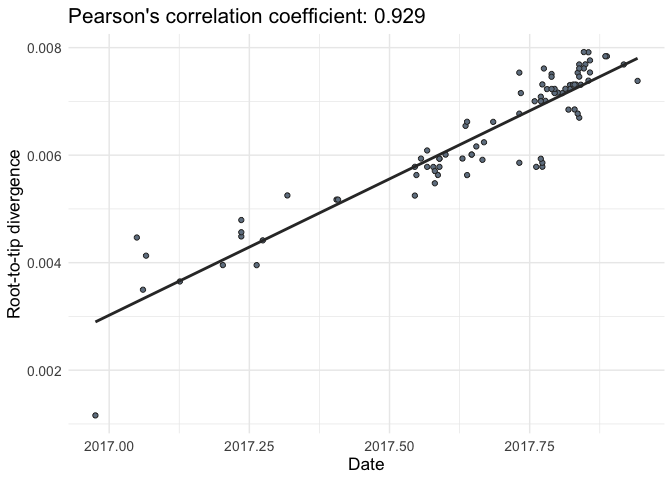

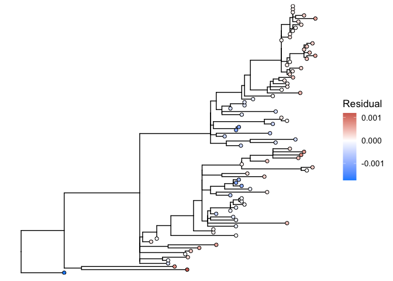